# Tidybiology Final Project

## Final Graph

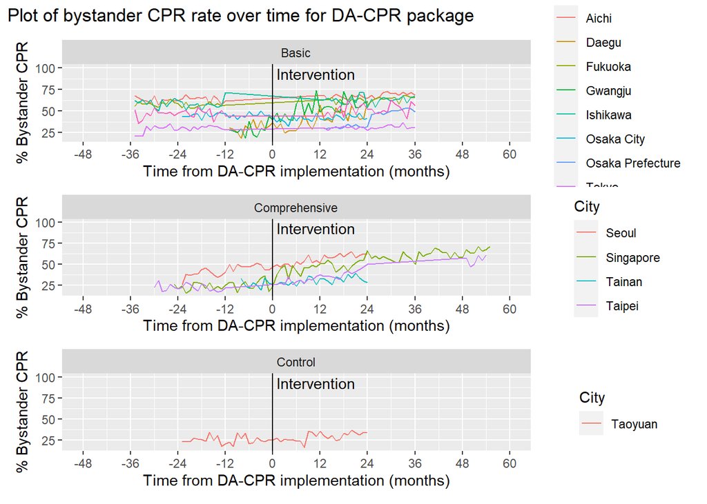

```r
# create summary data for plot (bcpr_percent to be plotted on y-axis)
dataforplot <-
  dacpr %>%
    group_by(timeFromImplementation, City, AnalysisGroup) %>%
    summarize(bcpr_percent = mean(by_cpr01, na.rm = TRUE)*100)
# split data for each "facet"
#dataSplitted <- split(dataforplot,f = dataforplot$AnalysisGroup)

# plot for the first "facet"
# p1 <- dataSplitted$Basic %>%
#   ggplot(aes(x = timeFromImplementation, y = bcpr_percent, color = City)) +
#     geom_line() +
#     facet_wrap(~AnalysisGroup, ncol=1) +
#     # here you set the axis
#     scale_x_continuous(limits = c(-48, 60),
#                        breaks = scales::breaks_width(12)) +
#     geom_vline(xintercept = 0) +
#     annotate("text", x = 1, y = 100, label = "Intervention", hjust = 0, vjust = 1) +
#     labs(x = "Time from DA-CPR implementation (months)",
#          y = "% Bystander CPR",
#          title = "Plot of bystander CPR rate over time for DA-CPR package")
# #    theme(plot.title = element_text(size = 20))
#
# # Do it for each facet of "AnalysisGroup"
# p2 <- p1 %+% dataSplitted$Comprehensive  # %+% replaces the data frame in a ggplot
# p3 <- p1 %+% dataSplitted$Control
#
# # Here is the plot
# bcprGraph <- grid.arrange(p1,p2,p3,ncol=1)
#bcprGraph <- grid.arrange(p1,p2,p3)
#save your new plot to have an image for your final presentation
# ggsave(here::here("6_final", "variation.png"), plot = last_plot(), height = 5, width = 7, units = "in", dpi = 300) #plan on changing the width:height ratio for your own plot


ggList <- lapply(split(dataforplot, dataforplot$AnalysisGroup), function(i) {
  ggplot(data = i, aes(x = timeFromImplementation, y = bcpr_percent, color = City)) +
    geom_line() +
    facet_wrap(~AnalysisGroup, ncol=1) +
    # here you set the axis
    scale_x_continuous(limits = c(-48, 60),
                       breaks = scales::breaks_width(12)) +
    geom_vline(xintercept = 0) +
    annotate("text", x = 1, y = 100, label = "Intervention", hjust = 0, vjust = 1) +
    labs(x = "Time from DA-CPR implementation (months)",
         y = "% Bystander CPR")#,
         #title = "Plot of bystander CPR rate over time for DA-CPR package")
})

finalplot <- cowplot::plot_grid(plotlist = ggList, ncol = 1,
                   align = 'v')#, labels = levels(dataforplot$City))

finalplot +
  plot_annotation(title = "Plot of bystander CPR rate over time for DA-CPR package")
```

```r
ggsave(here::here("MyGraphs", "bcpr_legendInFacet.png"), plot = last_plot(), height = 9, width = 7, units = "in", dpi = 300)
```

## Prioritized follow-up studies

I will proceed with interrupted time series analysis (ITSA); a type of regression based analysis for assessing immediate and long term effect of an implementation programme.

## Acknolwedgements

I would like to acknowledge the @rstudio team for making the tidyverse packages available for our easy use, the PAROS countries for collecting and participating in the study, Prof. Matthew Hirschey to teaching me this course and valuable help with this project (specially with import of SPSS dataset and advanced features of ggplot like facets and legend to create beautiful plots of journal publication quality .

#Session information for provenance and reproducibility

```r
#PROBABLY BEST TO LEAVE THIS HERE, BUT NO NEED TO PRINT IN THE FINAL REPORT.
```